# Notebook 20 – Solutions

## Getting Started

Before running this notebook, select “Session > Restart R and Clear Output” in the menu above to start a new R session. This will clear any old data sets and give us a blank slate to start with.

## Chicago Data

### Load the Data

For the last part of the semester we will be looking at a number of open data sets from the City of Chicago. We will load in several here:

```r
comarea <- read_sf(file.path("data", "chicago_community_areas.geojson"))
ziparea <- read_sf(file.path("data", "zip_codes.geojson"))
socio <- read_csv(file.path("data", "census_socioeconomic.csv"))
medical <- read_csv(file.path("data", "chicago_medical_examiner_cases.csv.gz"))

medical_geo <- medical %>%
  st_as_sf(coords = c("lon", "lat"), crs = 4326, remove = FALSE)
```

Today, our focus on the spatial components of the dataset. The spatial data contains information about zip codes and community areas. Specifically, we will look at a set of records by the Medican Examiner’s office showing deaths they have investigated:

```r
medical
```

```
## # A tibble: 34,566 × 14
##    date_incident_iso   date_death_iso      primary_cause     age gender race
##    <dttm>              <dttm>              <chr>           <dbl> <chr>  <chr>
##  1 2015-01-01 03:25:00 2015-01-01 03:10:00 HYPERTENSIVE A…    50 Male   Black
##  2 2014-12-08 18:37:00 2015-01-01 07:15:00 COMPLICATIONS …    89 Female White
##  3 2014-12-21 23:13:00 2015-01-01 08:45:00 COMPLICATIONS …    67 Male   Black
##  4 2015-01-01 09:07:00 2015-01-01 09:20:00 COMPLICATIONS …    31 Male   White
##  5 2015-01-01 09:54:00 2015-01-01 10:10:00 ASPHYXIATION       25 Male   White
##  6 2015-01-01 10:45:00 2015-01-01 11:19:00 HYPERTENSIVE A…    71 Male   White
##  7 2015-01-01 10:43:00 2015-01-01 11:22:00 DIABETIC KETOA…    61 Female Black
##  8 2015-01-01 12:00:00 2015-01-01 13:18:00 ALCOHOL TOXICI…    26 Male   White
##  9 2015-01-01 15:14:00 2015-01-01 15:30:00 ARTERIOSCLEROT…    56 Male   White
## 10 2015-01-01 15:27:00 2015-01-01 15:45:00 CHRONIC OBSTRU…    81 Female White
## # … with 34,556 more rows, and 8 more variables: latino <lgl>,
## #   gun_related <lgl>, opioid_related <lgl>, cold_related <lgl>,
## #   heat_related <lgl>, lon <dbl>, lat <dbl>, residence_zip <chr>
```

Most of these variables should be relatively self-explanatory.

## Practice

Pick a location in Chicago other than Millennium Park. Subset the medical data to within 1km of this location and plot the locations of the deaths over a map. Color the points according the race of the deceased.

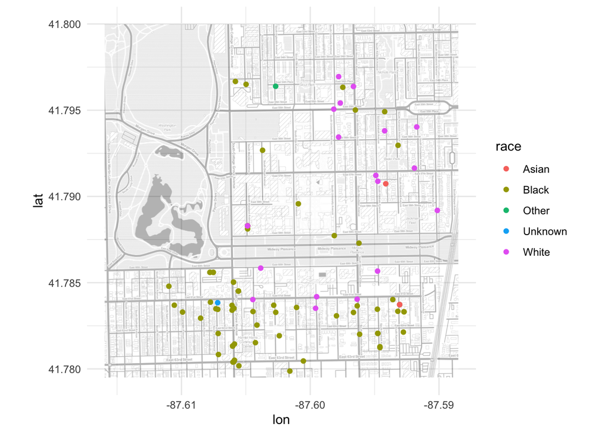

```r
u_chicago <- tibble(lon = -87.6009667, lat = 41.788452) %>%
  st_as_sf(coords = c("lon", "lat"), crs = 4326)

medical_geo %>%
  mutate(distance_mp = as.numeric(st_distance(geometry, u_chicago)) / 1000) %>%
  filter(distance_mp < 1) %>%
  ggplot(aes(lon, lat)) +
    stat_maptiles(alpha = 0.3) +
    geom_point(aes(color = race))
```

Draw a map of the zip codes data showing the number of opiod deaths that occurred in each zip code. Try to use a good color scale.

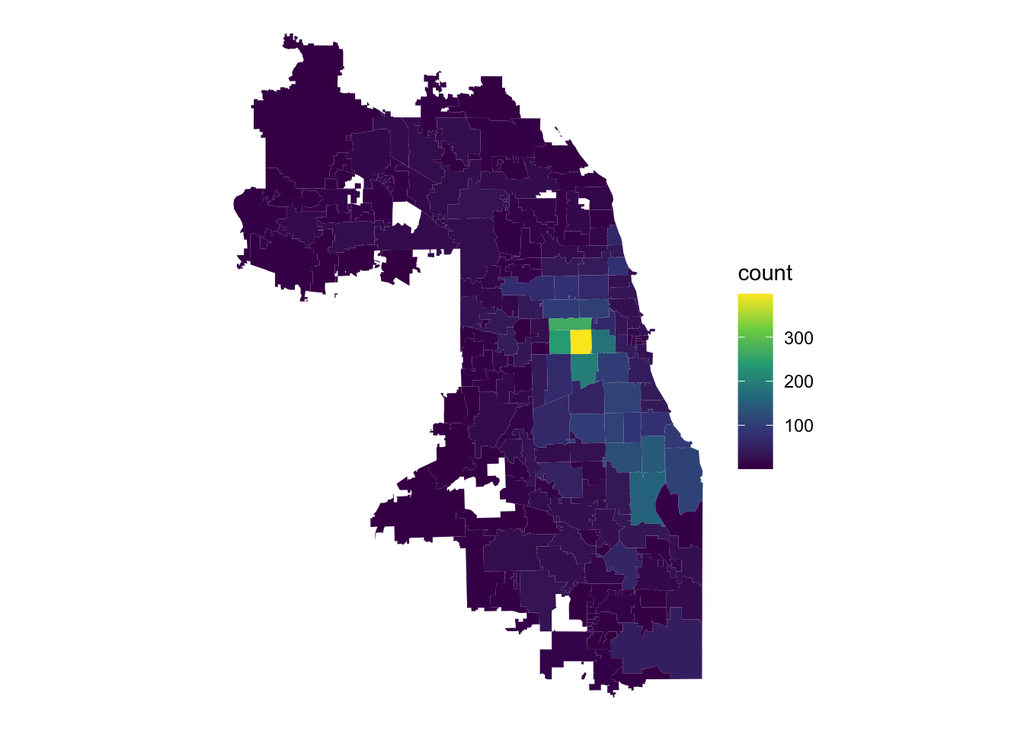

```r
ziparea %>%
  st_transform(4326) %>%
  spatial_join(medical_geo, left = FALSE) %>%
  filter(opioid_related) %>%
  group_by(zip) %>%
  summarize(sm_count()) %>%
  ggplot() +
    geom_sf(aes(fill = count), size = 0) +
    scale_fill_viridis_c() +
    theme_void()
```

There is another spatial dataset included here giving the community area in Chicago. Repeat the previous question with these regions.

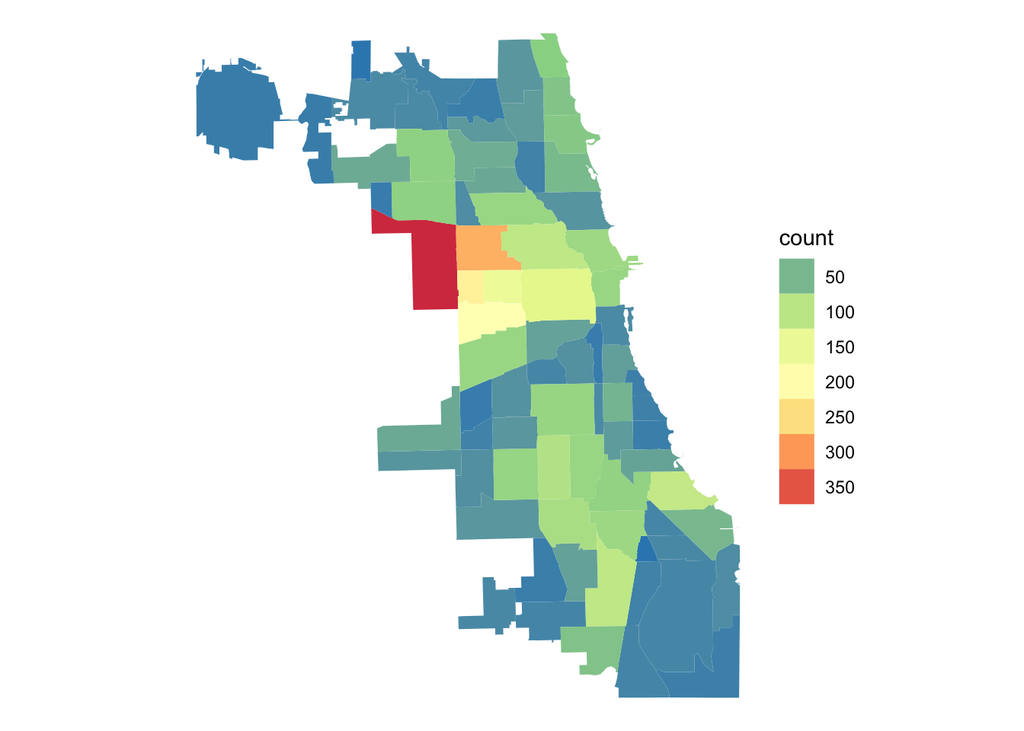

```r
comarea %>%
  st_transform(4326) %>%
  spatial_join(medical_geo, left = FALSE) %>%
  filter(opioid_related) %>%
  group_by(comarea_name) %>%
  summarize(sm_count()) %>%
  ggplot() +
    geom_sf(aes(fill = count), size = 0) +
    scale_fill_distiller(palette = "Spectral", guide = "legend", n.breaks = 10) +
    theme_void()
```

One advantage of the community areas is that we have socioeconomic covariates available in the data associated with each region. Draw a scatter plot with one point for each community area, showing the median income on the x-axis and the number of opioid deaths on the y-axis. Using labels to indicate the names of the community areas.

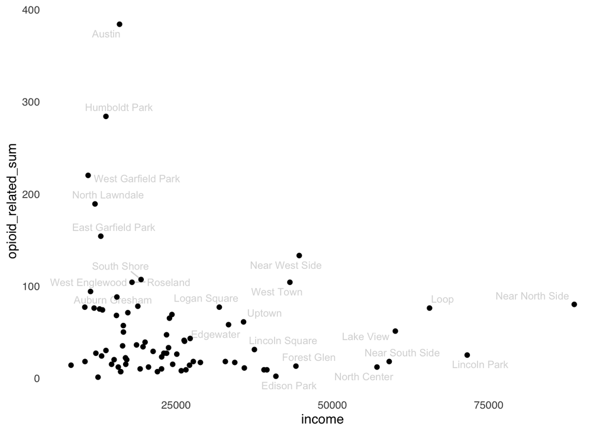

```r
medical_geo %>%
  spatial_join(st_transform(comarea, 4326), left = FALSE) %>%
  group_by(comarea, comarea_name) %>%
  summarise(sm_sum(opioid_related)) %>%
  left_join(socio, by = c("comarea", "comarea_name")) %>%
  ggplot(aes(income, opioid_related_sum)) +
    geom_text_repel(aes(label = comarea_name), size = 3, color = "grey85") +
    geom_point() +
    theme_sm()
```

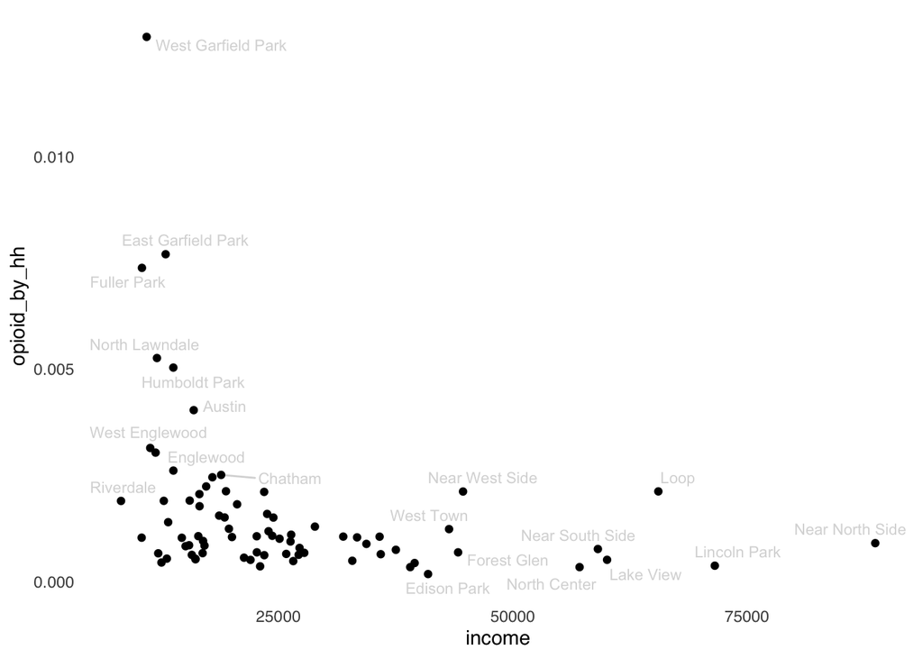

```r
medical_geo %>%
  spatial_join(st_transform(comarea, 4326), left = FALSE) %>%
  group_by(comarea, comarea_name) %>%
  summarise(sm_sum(opioid_related)) %>%
  left_join(socio, by = c("comarea", "comarea_name")) %>%
  mutate(opioid_by_hh = opioid_related_sum / population) %>%
  ggplot(aes(income, opioid_by_hh)) +
    geom_text_repel(aes(label = comarea_name), size = 3, color = "grey85") +
    geom_point() +
    theme_sm()
```